# Lecture 6 Demo: Gaussian Mixture Models on Penguins

STAT 24620 = STAT 32900, FINM 34700

Spring 2026

```r
library(palmerpenguins)
library(mclust)
```

## 1) Prepare the same penguins data used in Lecture 5

We reuse the same four numeric measurements and keep complete cases.

```r
raw_df <- penguins[, c(
  "species", "island",
  "bill_length_mm", "bill_depth_mm",
  "flipper_length_mm", "body_mass_g"
)]

keep <- complete.cases(raw_df)
penguins_df <- raw_df[keep, ]

X <- as.matrix(penguins_df[, c(
  "bill_length_mm", "bill_depth_mm",
  "flipper_length_mm", "body_mass_g"
)])

X_scaled <- scale(X)
```

## 2) Quick baseline: K-means (hard assignments)

```r
set.seed(32950)
km3 <- kmeans(X_scaled, centers = 3, nstart = 20)

table(km3$cluster)
```

```
  1   2   3
132  87 123
```

```r
table(TrueSpecies = penguins_df$species, KmeansCluster = km3$cluster)
```

```
           KmeansCluster
TrueSpecies   1   2   3
  Adelie    127  24   0
  Chinstrap   5  63   0
  Gentoo      0   0 123
```

## 3) Compute GMM using `MClust()`

### Model selection with BIC surface

Though GMM can model scale differences, the solution may not be stable if scales across variables differ a lot. So we still tend to scale the data first before running GMM in practice.

We use R function `Mclust()`. By default, it automatically select both number of components and covariance structure by BIC.

```r
set.seed(32950)
gmm_auto <- Mclust(X_scaled, G = 1:12, verbose = F) ## G: the possible numbers of components

summary(gmm_auto)
```

```
----------------------------------------------------
Gaussian finite mixture model fitted by EM algorithm
----------------------------------------------------

Mclust VEE (ellipsoidal, equal shape and orientation) model with 4 components:
```

|  | log-likelihood | n | df | BIC | ICL |
| --- | --- | --- | --- | --- | --- |
|  | -1154.901 | 342 | 32 | -2496.516 | -2535.667 |

```
Clustering table:
  1   2   3   4
154  66  57  65
```

The BIC in `MClust` is defined as the reverse of regularly defined BIC, so higher BIC represents better model in `MClust`:
$$\text{BIC}_{\text{mclust}} = -\text{BIC} =2l(\hat \Theta) - d\log n$$

We can actually visualize how BIC changes across different modeling choices.

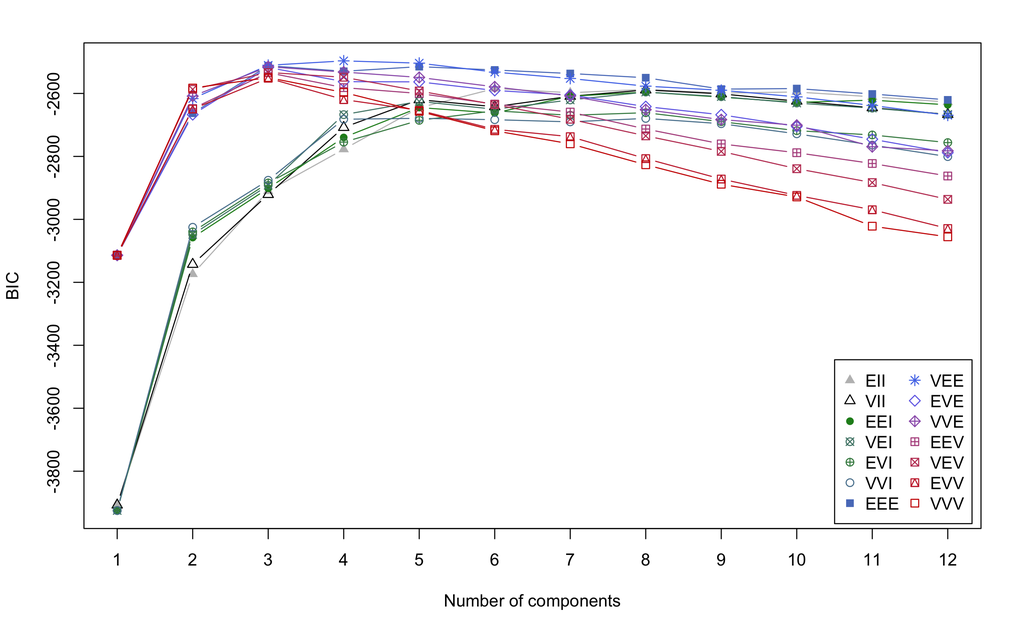

```r
plot(gmm_auto, what = "BIC")
```

You may also specify a specific convariance structure and number of components (for instance, fixed G = 3).

```r
gmm_3 <- Mclust(X_scaled, G = 3, modelNames = "VEE", verbose = F)
gmm_3$bic
```

```
[1] -2510.485
```

### The output of `Mclust`

We have the fitted model stored in `gmm_auto$paramters`, the estimated responsibilites stored in `gmm_auto$z`, and the corresponding hard clustering results in `gmm_auto$classification` and the uncertainties stored in `gmm_auto$uncertainty`.
$$\gamma_{ik} = P(Z_i=k\mid x_i), \quad \text{uncertainty}_i=1-\max_k\gamma_{ik}$$

```r
print("First 6 entries of the responsibilities:")
```

```
[1] "First 6 entries of the responsibilities:"
```

```r
head(gmm_auto$z)
```

```
          [,1]         [,2]         [,3]         [,4]
[1,] 0.9999859 7.831331e-42 1.088997e-27 1.405042e-05
[2,] 0.9997910 1.289681e-26 3.344178e-19 2.089817e-04
[3,] 0.9917237 7.758721e-30 1.436243e-21 8.276320e-03
[4,] 0.9999983 2.581199e-43 4.760017e-29 1.671648e-06
[5,] 0.9999928 1.510400e-52 3.022682e-33 7.230942e-06
[6,] 0.9999509 1.237485e-35 1.283305e-24 4.905485e-05
```

```r
print("First 6 entries of the uncertainty:")
```

```
[1] "First 6 entries of the uncertainty:"
```

```r
head(gmm_auto$uncertainty)
```

```
[1] 1.405042e-05 2.089817e-04 8.276320e-03 1.671648e-06 7.230942e-06 4.905485e-05
```

```r
print("First 6 entries of hard clustering labels:")
```

```
[1] "First 6 entries of hard clustering labels:"
```

```r
head(gmm_auto$classification)
```

```
[1] 1 1 1 1 1 1
```

## 4) Visualize the clustering results

`MClust` provides visualzation of clustering results in the original data space

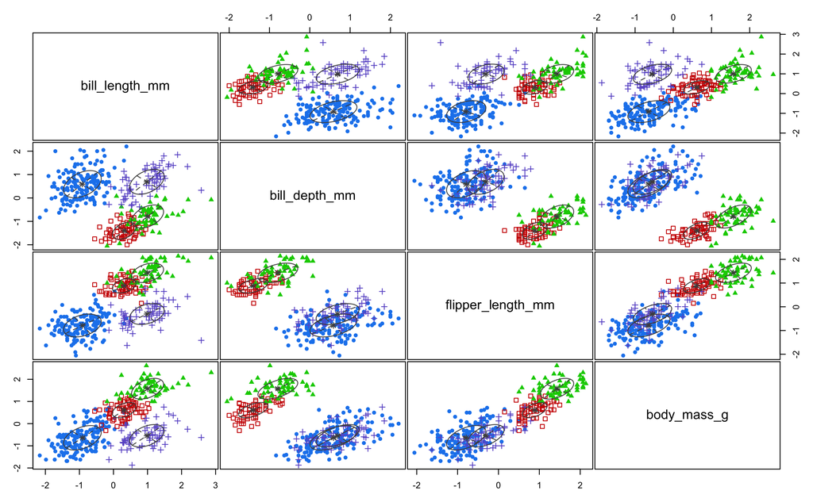

```r
plot(gmm_auto, what = "classification")
```

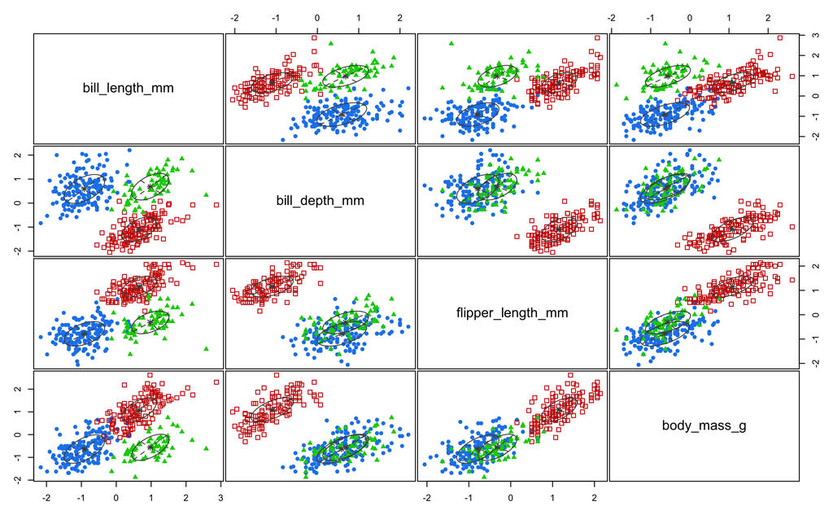

```r
plot(gmm_3, what = "classification")
```

Though BIC prefers $K = 4$, compared to the results when $K =3$, the additional cluster is not very well seperated in the data, so $K=3$ seems a more reasonable choice.

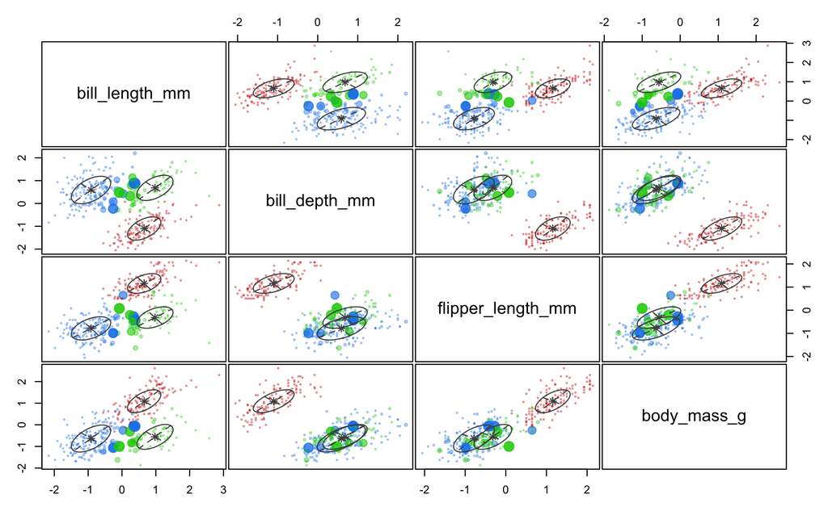

```r
plot(gmm_3, what = "uncertainty")
```

## 5) Visualize clustering results in PC space

```r
pca <- prcomp(X_scaled)
score12 <- pca$x[, 1:2]

op <- par(mfrow = c(2, 2), mar = c(4, 4, 2, 1))

plot(score12,
     col = penguins_df$species,
     pch = 19,
     xlab = "PC1", ylab = "PC2",
     main = "Ground truth (Species)")
legend("topright",
       legend = levels(as.factor(penguins_df$species)),
       col = 1:length(levels(as.factor(penguins_df$species))),
       pch = 19)
```

```r
plot(score12,
     col = km3$cluster,
     pch = 19,
     xlab = "PC1", ylab = "PC2",
     main = "K-means clusters")

plot(score12,
     col = gmm_3$classification,
     pch = 19,
     xlab = "PC1", ylab = "PC2",
     main = paste("GMM:", gmm_3$modelName, "(G=", gmm_3$G, ")"))
```

```r
plot(score12,
     col = "grey80",
     pch = 16,
     xlab = "PC1", ylab = "PC2",
     main = "GMM uncertainty (>0.1 highlighted)")

idx <- gmm_3$uncertainty > 0.1   # adjust threshold
points(score12[idx, ],
       col = "red",
       pch = 19)
```

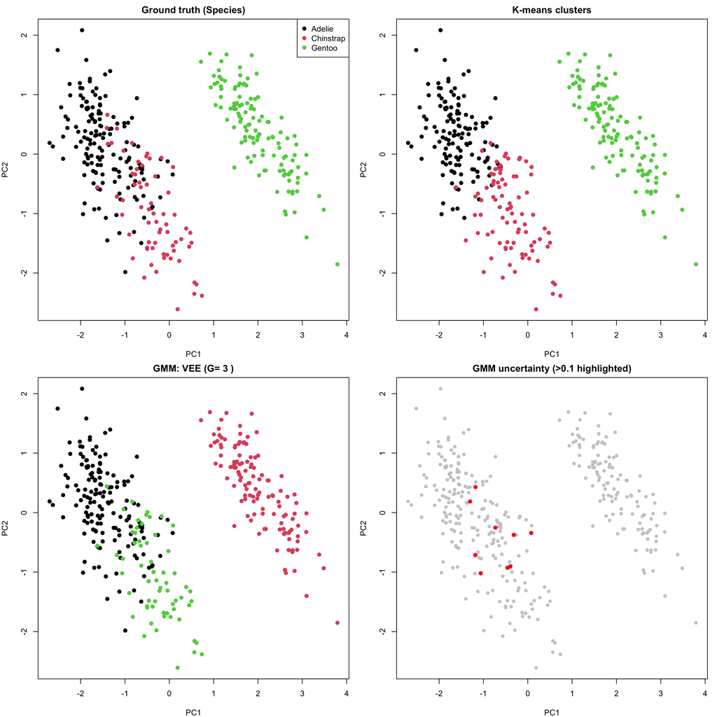

```r
par(op)
```

The GMM results are closer to the truth than K-means.

```r
species <- penguins_df$species

tab_kmeans <- table(Cluster = km3$cluster, Species = species)
tab_gmm  <- table(Cluster = gmm_3$classification, Species = species)

tab_kmeans
```

```
       Species
Cluster Adelie Chinstrap Gentoo
      1    127         5      0
      2     24        63      0
      3      0         0    123
```

```r
tab_gmm
```

```
       Species
Cluster Adelie Chinstrap Gentoo
      1    151         5      0
      2      0         0    123
      3      0        63      0
```

## 6) How covariance constraints change clustering (fixed G = 3)

To isolate covariance assumptions, hold `G = 3` fixed and compare BIC values.

```r
cov_models <- c(
  "EII", # spherical, equal volume
  "VII", # spherical, unequal volume
  "VEE", # ellipsoidal, equal shape and orientation
  "VVV"  # ellipsoidal, varying covariance (most flexible)
)

fits_cov <- lapply(cov_models, function(m) {
  Mclust(X_scaled, G = 3, modelNames = m, verbose = F)
})
names(fits_cov) <- cov_models

bic_cov <- sapply(fits_cov, function(f) f$bic)
comparison_table <- data.frame(
  model = cov_models,
  BIC = round(as.numeric(bic_cov), 2)
)
comparison_table <- comparison_table[order(-comparison_table$BIC), ]
comparison_table
```

|  | model | BIC |
| --- | --- | --- |
| 3 | VEE | -2510.48 |
| 4 | VVV | -2549.61 |
| 1 | EII | -2910.12 |
| 2 | VII | -2920.98 |

Visualize how the covariance choices change the final clustering results

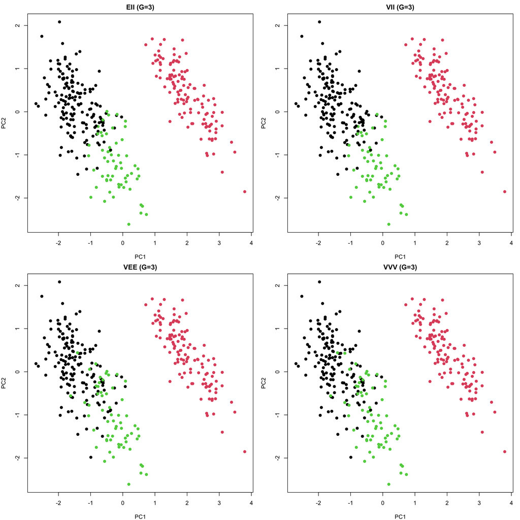

```r
op <- par(mfrow = c(2, 2), mar = c(4, 4, 2, 1))

for (m in cov_models) {
  plot(score12,
       col = fits_cov[[m]]$classification,
       pch = 19,
       xlab = "PC1", ylab = "PC2",
       main = paste0(m, " (G=3)"))
}

par(op)
```

## 9) Takeaways

- K-means gives **hard** assignments only.
- GMM gives **soft** assignments via posterior probabilities.
- Different covariance constraints imply different geometric assumptions, making GMM more flexible than K-means.
- BIC helps compare both number of components and covariance structure.